# Chapter 5 MANOVA

**Hotelling’s T² Test and Multivariate Analysis of Variance (MANOVA)**  
Hotelling’s T² test is the multivariate counterpart of the two-sample *t*-test, while MANOVA extends ANOVA to assess group differences across multiple dependent variables simultaneously.

### Review of hypothesis testing

After collecting sample data through an observational study or experiment, statistical inference enables analysts to evaluate evidence supporting a claim about the population from which the sample was taken. Hypothesis testing, also referred to as tests of significance, are the methods to either accept (fail to reject) or reject claims based on sample data. The objective of hypothesis testing is to access the amount of the evidence in the sample in favor of a particular claim regarding population parameter(s).

The p-value, or probability value, is a measure in hypothesis testing to determine the amount of the evidence against the null hypothesis.

$$ P-value = P( \mbox{data or more exetreme situations} | H0) $$

It is the probability of obtaining results as extreme as, or more extreme than, the observed results, under the assumption that the null hypothesis is true. It tells you how likely it is to observe the data, or more extreme data, if the null hypothesis is actually true. A smaller p-value indicates stronger evidence against the null hypothesis, suggesting that the observed data is unlikely to have occurred if the null hypothesis were true. Typically, if the p-value is less than a predetermined significance level ($\alpha$), the null hypothesis is rejected, indicating that there is sufficient evidence to support the alternative hypothesis. Conversely, if the p-value is greater than the significance level, fail to reject the null hypothesis , suggesting that there is not enough evidence to support the alternative hypothesis.

#### One sample t-test:

The one-sample t-test is a statistical procedure used to determine whether the population mean of a single sample differs significantly from a hypothesized value. It is typically applied when you have a single group of observations and want to compare their mean value on a continuous variable against a hypothesized benchmark.

**Example:**  
Odometers are used to gauge automobile mileage, but how accurately do they reflect the actual distance traveled? Suppose 12 cars travel a predetermined distance of exactly 10 miles, and the recorded mileage values from their odometers are:

$9.8,\; 10.1,\; 10.3,\; 10.2,\; 9.9,\; 10.4,\; 10.0,\; 9.9,\; 10.3,\; 10.0,\; 10.1,\; 10.2$

### (a) Test whether the odometer is inaccurate in terms of the population mean

- Hypotheses:  
  $H_0: \mu = 10$  
  $H_1: \mu \ne 10$
- Method: One-sample t-test (assuming data are approximately normally distributed).  
  Normality can be checked using a QQ plot.
- Results:  
  $t = 1.8638$ (calculated by formula or R)  
  $p$-value $= 0.08924$
- Conclusion: Since $p$-value $> 0.05$, we fail to reject $H_0$. There is insufficient evidence to conclude that the population mean of the odometer readings systematically deviates from 10.

### (b) Test whether the odometer systematically overestimates the actual mileage

- Hypotheses:  
  $H_0: \mu = 10$  
  $H_1: \mu > 10$
- Results:  
  $t = 1.8638$ (calculated by formula or R)  
  $p$-value $= 0.04462$
- Conclusion: Since $p$-value $< 0.05$, we reject $H_0$. There is sufficient evidence to conclude that the population mean of the odometer readings is greater than 10.

```
	One Sample t-test

data:  x
t = 1.8638, df = 11, p-value = 0.08924
alternative hypothesis: true mean is not equal to 10
95 percent confidence interval:
  9.981908 10.218092
sample estimates:
mean of x
     10.1
```

```
	One Sample t-test

data:  x
t = 1.8638, df = 11, p-value = 0.04462
alternative hypothesis: true mean is greater than 10
95 percent confidence interval:
 10.00364      Inf
sample estimates:
mean of x
     10.1
```

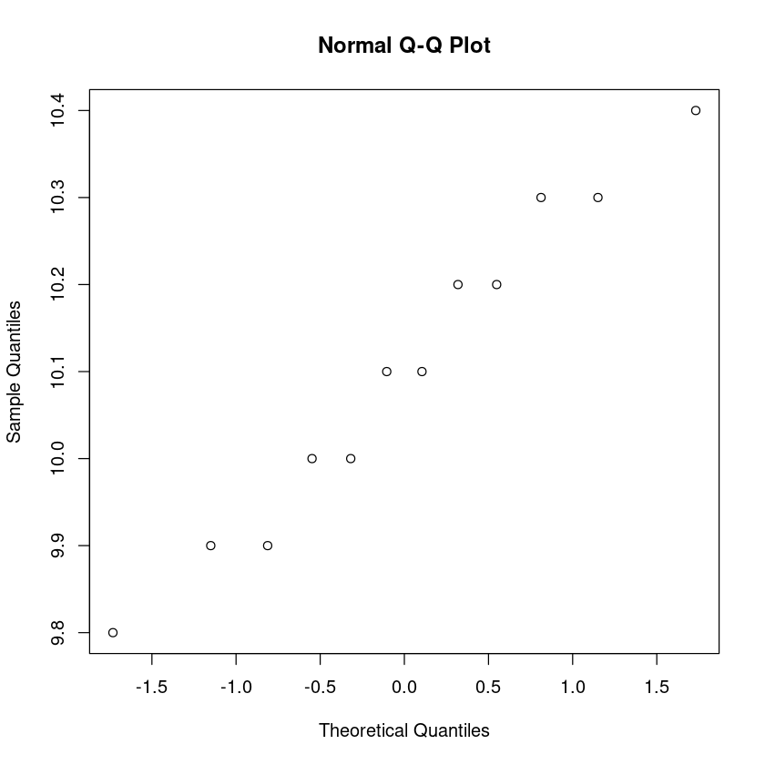

```r
#one sample t test for (a)

x = c(9.8, 10.1, 10.3, 10.2, 9.9, 10.4, 10.0, 9.9, 10.3, 10.0, 10.1, 10.2)
t.test(x, alternative = "two.sided", mu=10 )

qqnorm(x)
#According to ... , it seems that the normality assumption is ok.

##one sample t test for (b)
t.test(x, alternative = "greater", mu=10 )
```

### The one-sample Hotelling’s T2 test

**The one-sample Hotelling’s T² test** is the multivariate counterpart of the traditional one-sample or paired Student’s *t*-test. While the one-sample *t*-test compares the population mean of a single variable to a specified value, Hotelling’s one-sample T² test extends this framework to cases involving two or more response variables (though it also reduces to the *t*-test when there is only one response variable).

The primary purpose of the one-sample Hotelling’s T² test is to determine whether the population mean vector is equal to a given mean vector when there are multiple response variables.

Formally, the hypotheses can be stated as:

$H_0: {\mu} $ = a given vector of known numbers

$H_1: {\mu} \ne $ the given vector of known numbers

### Formula for one-sample Hotelling's T^2 test

$$ T^2 = (\bar{x} - \mu_0)^{\prime} \left(\tfrac{1}{n}\mathbf{S}\right)^{-1} (\bar{x} - \mu_0) = n(\bar{x} - \mu_0)^{\prime}\mathbf{S}^{-1}(\bar{x} - \mu_0) $$$$ T^2 \sim \frac{(n-1)p}{\,n-p\,} F_{p,\,n-p} $$$$ P\!\left(F_{p,\,n-p} > \frac{(n-p)}{(n-1)p}T^2 \right) $$

Example: Run a test to determine whether the population mean vector of Total_length, Alar_extent, and L_beak_head differs from $(150, 240, 34)$.

R codes:

```r
library(MVTests)

#Load the file in datasciences.tamucc.edu
loc1 ="~//distribute_files//data//Bumpus_sparrows.csv"
sparrow1.dat = read.csv( loc1,  header = 1 )

#Data matrix
dat = sparrow1.dat[, -1]
head(dat)

#One sample Hotelling T test
OneSampleHT2(dat[, c(1,2,3)],mu=c(150, 240, 34))
```

A data.frame: 6 × 5

|  | Total_length <int> | Alar_extent <int> | L_beak_head <dbl> | L_humerous <dbl> | L_keel_sternum <dbl> |
| --- | --- | --- | --- | --- | --- |
| 1 | 156 | 245 | 31.6 | 18.5 | 20.5 |
| 2 | 154 | 240 | 30.4 | 17.9 | 19.6 |
| 3 | 153 | 240 | 31.0 | 18.4 | 20.6 |
| 4 | 153 | 236 | 30.9 | 17.7 | 20.2 |
| 5 | 155 | 243 | 31.5 | 18.6 | 20.3 |
| 6 | 163 | 247 | 32.0 | 19.0 | 20.9 |

**$HT2**

A matrix: 1 × 1 of type dbl

| 2117.639 |
| --- |

**$F**

A matrix: 1 × 1 of type dbl

| 676.468 |
| --- |

**$df**

1. 3

2. 46

**$p.value**

A matrix: 1 × 1 of type dbl

| 4.849606e-38 |
| --- |

**$CI**

A data.frame: 3 × 4

|  | Lower <dbl> | Upper <dbl> | Mu0 <dbl> | Important Variables? <chr> |
| --- | --- | --- | --- | --- |
| Total_length | 156.43215 | 159.52704 | 150 | *TRUE* |
| Alar_extent | 239.18051 | 243.47256 | 240 | FALSE |
| L_beak_head | 31.12264 | 31.79573 | 34 | *TRUE* |

**$alpha**

0.05

**$Descriptive**

A matrix: 3 × 3 of type dbl

|  | Total_length | Alar_extent | L_beak_head |
| --- | --- | --- | --- |
| N | 49.000000 | 49.000000 | 49.0000000 |
| Means | 157.979592 | 241.326531 | 31.4591837 |
| Sd | 3.654277 | 5.067822 | 0.7947532 |

**$Test**

'OneSampleHT2'

### The hypothesis testing for the problem is reported as below:

$$ H_0 : \mu^T = (150, 240, 34) \quad \text{vs.} \quad H_1 : \mu^T \ne (150, 240, 34) $$

**Assumption:**  
The data follow a multivariate normal distribution (Please check using a multivariate Q-Q plot).

**Calculation in R:**

```
OneSampleHT2(dat[, c(1,2,3)], mu = c(150, 240, 34))
```

**Results:**

- Hotelling’s T² = 2117.639
- Test statistic: $F = 676.468$
- $p$-value = 0.00000

**Conclusion:**

Reject $H_0$. There is sufficient evidence to support $H_1$, indicating that the population mean vector of *(Total_length, Alar_extent, L_beak_head)* differs from $(150, 240, 34)$.

### The following example is based on formula:

Question: Conduct a test to check if the population average of both (Total_length, Alar_extent) is different than (150, 235).

The R codes below is the calculation using formula. Please check the answer.

```r
#Data matrix
mean.vec = sapply(dat[,1:2], mean)
mean.vec = as.vector(mean.vec)
mean.vec

mean.hypothesized = c(150, 235)

S.cov = cov(dat[,1:2])
S.cov

n = length(dat[,1])

n

#The calculation of one sample  Hotelling T
#solve(S.cov)  ==> get the inverse of S.cov
T2 = n*t(mean.vec - mean.hypothesized)%*% solve(S.cov)%*% (mean.vec - mean.hypothesized)
T2

#To get the p-value,
#The reference distribution is an F distribuiton with degrees of freedom p, n-p , wehere p is the number of variable)
# p =2
#F distribution with degree freedom = 2, 49 -2 = 47

p=2
#pf(x, df1, df2) is the find the probability no more than a number x for an F distribution with ...
pvalue = 1 - pf(  T2*(n-p)/(p*(n-1)),  p, n-p  )

pvalue

#Since the pvalue is 0, which is smaller than the level of significance (0.05). Reject H0.
#There is sufficient evidence that the mean vector of (Total_length, Alar_extent) is different than (150, 235).

#Check the normality assumption :  multivariate normal - multivariate QQ nomral plot
```

1. 157.979591836735

2. 241.326530612245

A matrix: 2 × 2 of type dbl

|  | Total_length | Alar_extent |
| --- | --- | --- |
| Total_length | 13.35374 | 13.61097 |
| Alar_extent | 13.61097 | 25.68282 |

49

A matrix: 1 × 1 of type dbl

| 247.1884 |
| --- |

A matrix: 1 × 1 of type dbl

| 0 |
| --- |

# Review of Two-Sample t Test

Researchers conducted a study to compare the efficacy of two mosquito repellents. Two groups of participants were tested, and the outcome was measured as the number of mosquito bites experienced:

- **Repellent A:** 5, 12, 33, 17, 9, 3, 6, 12, 20, 14, 7, 12, 25, 6, 4, 5
- **Repellent B:** 12, 19, 36, 15, 18, 7, 5, 12, 26, 57, 10, 11, 22, 13, 11, 5

At a significance level of **0.01**, the study aims to determine whether there is sufficient evidence to support the claim that Repellent A is more effective than Repellent B.

To compare the two groups in terms of their population means, we set up the hypotheses:

- Null hypothesis:
  $$H_0: \mu_1 = \mu_2$$
- Alternative hypothesis:
  $$H_1: \mu_1 < \mu_2$$

where $\mu_1$ is the mean number of bites after using Repellent A and $\mu_2$ is the mean number of bites after using Repellent B.

```
	Welch Two Sample t-test

data:  x.A and x.B
t = -1.4167, df = 25.292, p-value = 0.08438
alternative hypothesis: true difference in means is less than 0
95 percent confidence interval:
     -Inf 1.141094
sample estimates:
mean of x mean of y
  11.8750   17.4375
```

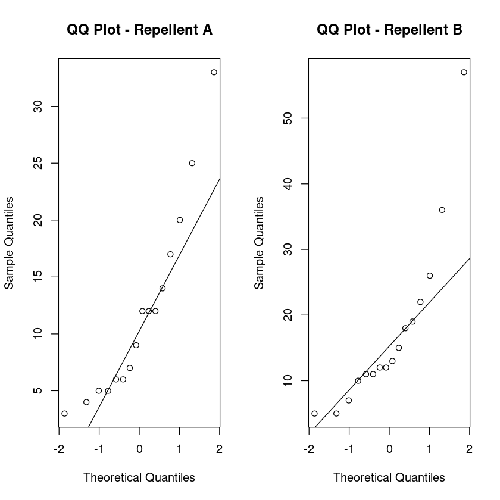

```r
# Two sample t test: Repellent A vs Repellent B

# Data
x.A = c(5, 12, 33, 17, 9, 3, 6, 12, 20, 14, 7, 12, 25, 6, 4, 5)
x.B = c(12, 19, 36, 15, 18, 7, 5, 12, 26, 57, 10, 11, 22, 13, 11, 5)

# Two-sample t test (Welch’s test: unequal variances)
t.test(x.A, x.B, alternative = "less", var.equal = FALSE)

# If we assume equal variances (pooled t test)
#t.test(x.A, x.B, alternative = "less", var.equal = TRUE)

# Normality check using QQ plots
par(mfrow=c(1,2))  # Show both plots side by side
qqnorm(x.A, main="QQ Plot - Repellent A")
qqline(x.A)
qqnorm(x.B, main="QQ Plot - Repellent B")
qqline(x.B)
par(mfrow=c(1,1))

# According to the QQ plots, if the points lie roughly on a straight line,
# the normality assumption is considered reasonable.

# Usually , the level of significance is given in a question,
# If it is not given, use 0.05 as the default value for the level of significnce
# Reject H0 if p-value is less or (=) than the level of significance
# Fail to reject H0 if p-value is greater than the level of significance
```

Since the p-value = 0.08438, which is greater than 0.01, we **fail to reject** $H_0$.  
There is insufficient evidence to conclude that Repellent A is more effective than Repellent B at the 1% significance level.

What are the decision and the conclusion if the level of significance is 0.1 for the problem?

The p-value = 0.08438, which is less than 0.10, so we **reject** $H_0$.  
There is sufficient evidence to conclude that Repellent A is more effective than Repellent B at the 10% significance level.

### Assumptions for the Two-Sample *t*-Test

- The two samples are independent.
- Each group (Repellent A and Repellent B) follows an approximately normal distribution.

--- ..

# The two-sample Hotelling’s T2 test

The two-sample Hotelling’s T² test is the multivariate extension of the two-sample t-test. It is used to determine whether the mean vectors of two groups differ significantly across multiple correlated dependent variables.

$H_0: (\mu_1, \mu_2, \cdots, \mu_k) = (v_1, v_2, \cdots, v_k)$

where $(\mu_1, \mu_2, \cdots, \mu_k)$ and $(v_1, v_2, \cdots, v_k)$ are the population mean vectors of two groups. The purpose of the two-sample Hotelling’s T2 test is to test if two population mean vectors of two groups are the same or not.

\begin{align} \mathbf{S}_p &= \frac{(n_1 - 1)\mathbf{S}_1 + (n_2 - 1)\mathbf{S}_2}{n_1 + n_2 - 2} \\[2mm] T^2 &= \frac{n_1 n_2}{n_1 + n_2} (\mathbf{\bar{X}}_1 - \mathbf{\bar{X}}_2)^\top \mathbf{S}_p^{-1} (\mathbf{\bar{X}}_1 - \mathbf{\bar{X}}_2) \\[1mm] F &= \frac{(n_1 + n_2 - p - 1) T^2}{(n_1 + n_2 - 2)p} \sim F_{p,\, n_1 + n_2 - p - 1} \end{align}$$ \begin{aligned} \mathbf{\bar{X}}_1 &\text{ = mean vector of Group 1} \\ \mathbf{\bar{X}}_2 &\text{ = mean vector of Group 2} \\ \mathbf{S}_1 &\text{ = covariance matrix of Group 1} \\ \mathbf{S}_2 &\text{ = covariance matrix of Group 2} \\ \mathbf{S}_p &\text{ = pooled covariance matrix} \\ n_1, n_2 &\text{ = sample sizes of the two groups} \\ p &\text{ = number of dependent variables} \end{aligned} $$

$p\text{-value} = P\!\left(F_{p,\, n_1 + n_2 - p - 1} > F\right)$

# Example :

Using the sparrow survival dataset, test whether the population mean vector of $(\text{Total_length}, \text{Alar_extent}, \text{L_beak_head})$ for the survived group is equal to that of the unsurvived group.

```r
head(sparrow1.dat)

Survived= dat[sparrow1.dat$Survivorship=='S',]
NSurvived= dat[sparrow1.dat$Survivorship=='NS',]
```

A data.frame: 6 × 6

|  | Survivorship <chr> | Total_length <int> | Alar_extent <int> | L_beak_head <dbl> | L_humerous <dbl> | L_keel_sternum <dbl> |
| --- | --- | --- | --- | --- | --- | --- |
| 1 | S | 156 | 245 | 31.6 | 18.5 | 20.5 |
| 2 | S | 154 | 240 | 30.4 | 17.9 | 19.6 |
| 3 | S | 153 | 240 | 31.0 | 18.4 | 20.6 |
| 4 | S | 153 | 236 | 30.9 | 17.7 | 20.2 |
| 5 | S | 155 | 243 | 31.5 | 18.6 | 20.3 |
| 6 | S | 163 | 247 | 32.0 | 19.0 | 20.9 |

```
Call: mardia(x = Survived[, 1:3])

Mardia tests of multivariate skew and kurtosis
Use describe(x) the to get univariate tests
n.obs = 21   num.vars =  3
b1p =  2.96   skew =  10.37  with probability  <=  0.41
 small sample skew =  12.71  with probability <=  0.24
b2p =  12.79   kurtosis =  -0.93  with probability <=  0.35
```

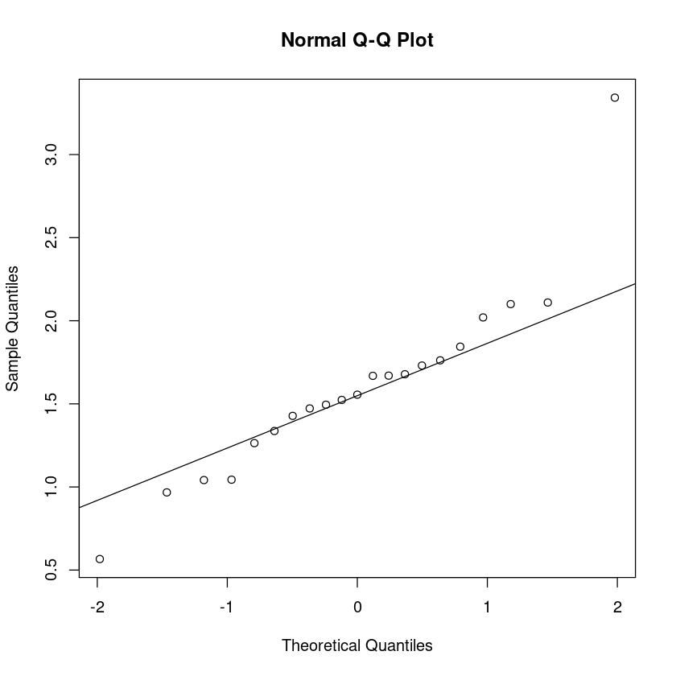

```
Call: mardia(x = NSurvived[, 1:3])

Mardia tests of multivariate skew and kurtosis
Use describe(x) the to get univariate tests
n.obs = 28   num.vars =  3
b1p =  2.5   skew =  11.67  with probability  <=  0.31
 small sample skew =  13.62  with probability <=  0.19
b2p =  12.4   kurtosis =  -1.25  with probability <=  0.21
```

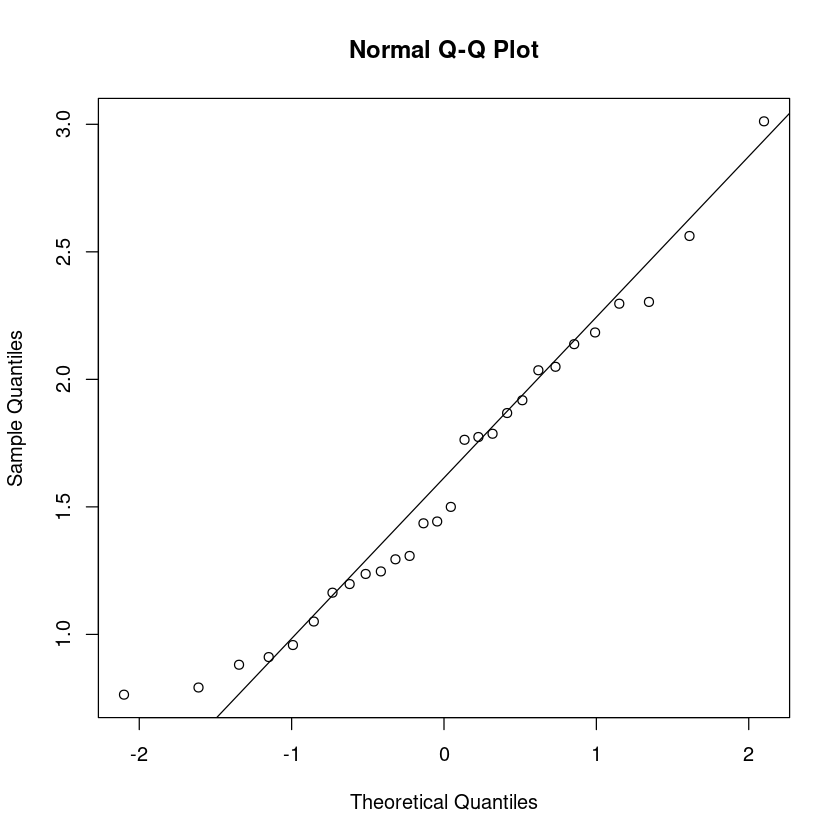

```r
#Check the normality of both groups
library(psych)


Survived= dat[sparrow1.dat$Survivorship=='S',]
NSurvived= dat[sparrow1.dat$Survivorship=='NS',]

#Multivariate QQ Normal plots for multivariate data (survived cases) of the first three variables
mardia(Survived[,1:3])

#Multivariate  Normal QQ plots for multivariate data (not survived cases)
mardia(NSurvived[,1:3])




#It seems that the data of the survived cases are form a slightly non-normality distribution.
#It seems that the data of the non-survived cases are form a normality distribution approximately.
# It is relatively safe to run ...

#TwoSampleT2Test(X = Survived[,1:3],  Y= NotSurvived[,1:3])
```

### The results are reported below:

$$ H_0 : \mu^T_S = \mu^T_{NS}; \quad H_1 : \mu^T_S \ne \mu^T_{NS} $$

where $\mu^T_S$ and $\mu^T_{NS}$ are the population mean vectors of survived cases, non-survived cases respectively.

```r
#grp takes only two values 1, 2
index.s=sparrow1.dat$Survivorship == 'S'
#Define an indicator
sparrow1.dat$grp = rep(1, length(index.s))
sparrow1.dat$grp[!index.s] = 2

head(sparrow1.dat)
```

A data.frame: 6 × 7

|  | Survivorship <chr> | Total_length <int> | Alar_extent <int> | L_beak_head <dbl> | L_humerous <dbl> | L_keel_sternum <dbl> | grp <dbl> |
| --- | --- | --- | --- | --- | --- | --- | --- |
| 1 | S | 156 | 245 | 31.6 | 18.5 | 20.5 | 1 |
| 2 | S | 154 | 240 | 30.4 | 17.9 | 19.6 | 1 |
| 3 | S | 153 | 240 | 31.0 | 18.4 | 20.6 | 1 |
| 4 | S | 153 | 236 | 30.9 | 17.7 | 20.2 | 1 |
| 5 | S | 155 | 243 | 31.5 | 18.6 | 20.3 | 1 |
| 6 | S | 163 | 247 | 32.0 | 19.0 | 20.9 | 1 |

```r
#Two sample hotelling t test
#sparrow1.dat
#Total_length, Alar_extent, L_beak_head :
#Function for two sample Hotelling T test in package "MVtests" or ...
TwoSamplesHT2(sparrow1.dat[,c(2,3,4)], group=sparrow1.dat$grp)

#Test statistic T2 = 1.4638
#F-value = 0.467
#p-value = 0.706624

#Since p-value 0.706 is greater than 0.05, fail to reject H0.
#conclusion:  fail to reject H0. There is no sufficient evidence that the population
# means of Total_length, Alar_extent, L_beak_head are different between survived cases and not survived cases.
```

**$HT2**

A matrix: 1 × 1 of type dbl

| 1.463875 |
| --- |

**$F**

A matrix: 1 × 1 of type dbl

| 0.4671943 |
| --- |

**$df**

1. 3

2. 45

**$p.value**

A matrix: 1 × 1 of type dbl

| 0.706624 |
| --- |

**$CI**

A data.frame: 3 × 3

|  | Lower <dbl> | Upper <dbl> | Important Variables? <chr> |
| --- | --- | --- | --- |
| Total_length | -4.1791024 | 2.0838643 | FALSE |
| Alar_extent | -4.9525657 | 3.8097086 | FALSE |
| L_beak_head | -0.7331188 | 0.6426426 | FALSE |

**$alpha**

0.05

**$Descriptive1**

A matrix: 2 × 3 of type dbl

|  | Total_length | Alar_extent | L_beak_head |
| --- | --- | --- | --- |
| Means | 157.380952 | 241.0000 | 31.4333333 |
| Sd | 3.323796 | 4.1833 | 0.7289262 |

**$Descriptive2**

A matrix: 2 × 3 of type dbl

|  | Total_length | Alar_extent | L_beak_head |
| --- | --- | --- | --- |
| Means | 158.428571 | 241.571429 | 31.478571 |
| Sd | 3.881853 | 5.705284 | 0.853471 |

**$Test**

'TwoSamplesHT2'

```r
#Self defined Function for two sample Hotelling t test
TwoSampleT2Test = function(X, Y)
{
nx = nrow(X)
ny = nrow(Y)
#The difference between two sample mean vectors
delta = colMeans(X) - colMeans(Y)

#This is the number of variables
p = ncol(X)
Sx = cov(X)
Sy = cov(Y)

#To obtain the pooled covaraince matrix of two groups
S_pooled = ((nx-1)*Sx + (ny-1)*Sy)/(nx+ny-2)

#Hotelling T
T_squared =  (nx*ny)/(nx+ny) * t(delta) %*% solve(S_pooled) %*% (delta)

#F-statistic
statistic = T_squared * (nx+ny-p-1)/(p*(nx+ny-2))

p_value = pf(statistic, p, nx+ny-p-1, lower.tail=FALSE)
return(list(Test.Statistic=statistic, p.value=p_value, df1=p, df2=nx+ny-p-1))
}

#How to use it:  to compare the population mean vector of X group vs Y group
#TwoSampleT2Test(X,  Y)
#Data for the the variables "Total_length, Alar_extent, L_beak_head " of survived cases :
S.dat = sparrow1.dat[index.s,c(2,3,4)]
#Data for the the variables "Total_length, Alar_extent, L_beak_head " of non-survived cases :
NS.dat =  sparrow1.dat[!index.s,c(2,3,4)]
TwoSampleT2Test(X=S.dat, Y=NS.dat)
```

**$Test.Statistic**

A matrix: 1 × 1 of type dbl

| 0.4671943 |
| --- |

**$p.value**

A matrix: 1 × 1 of type dbl

| 0.706624 |
| --- |

**$df1**

3

**$df2**

45

Exercise: Use *Proj1.csv* from Canvas. Run a test to determine whether the population means of all variables are the same for males and females.

```r
loc = "Proj1.csv"

dat = read.csv( loc, header  = 1)

head(dat)

pdat = dat

#grp takes only two values 1, 2
index.s=dat$Sex == 'M'
#Define an indicator
pdat$grp = rep(1, length(index.s))
pdat$grp[!index.s] = 2
```

A data.frame: 6 × 16

|  | Sex <chr> | Log..GM. <dbl> | GCL <dbl> | NL <dbl> | RW <dbl> | MAW <dbl> | GCD <dbl> | DM2 <dbl> | MRD <dbl> | LD <dbl> | GCW <dbl> | IMW <dbl> | PW <dbl> | LDL <dbl> | DMND <dbl> | MANL <dbl> |
| --- | --- | --- | --- | --- | --- | --- | --- | --- | --- | --- | --- | --- | --- | --- | --- | --- |
| 1 | F | 1.18 | 0.51 | 0.03 | -0.16 | 0.31 | -0.01 | 0.08 | -0.17 | 0.12 | 0.25 | -0.24 | -0.68 | -0.14 | -0.26 | 0.36 |
| 2 | F | 1.17 | 0.51 | 0.03 | -0.16 | 0.31 | 0.03 | 0.08 | -0.15 | 0.10 | 0.25 | -0.23 | -0.74 | -0.14 | -0.26 | 0.37 |
| 3 | F | 1.21 | 0.51 | 0.06 | -0.10 | 0.32 | 0.00 | 0.08 | -0.17 | 0.12 | 0.25 | -0.23 | -0.74 | -0.14 | -0.30 | 0.36 |
| 4 | F | 1.23 | 0.52 | 0.07 | -0.10 | 0.30 | 0.00 | 0.07 | -0.14 | 0.09 | 0.26 | -0.27 | -0.77 | -0.17 | -0.24 | 0.38 |
| 5 | F | 1.19 | 0.53 | 0.05 | -0.14 | 0.30 | 0.00 | 0.07 | -0.14 | 0.10 | 0.29 | -0.24 | -0.82 | -0.13 | -0.24 | 0.37 |
| 6 | F | 1.16 | 0.51 | 0.03 | -0.15 | 0.28 | 0.02 | 0.06 | -0.20 | 0.10 | 0.30 | -0.21 | -0.70 | -0.14 | -0.26 | 0.34 |

```r
library(MVTests)

TwoSamplesHT2(pdat[,2:16], group=pdat$grp)
```

**$HT2**

A matrix: 1 × 1 of type dbl

| 31.81168 |
| --- |

**$F**

A matrix: 1 × 1 of type dbl

| 2.087192 |
| --- |

**$df**

1. 15

2. 870

**$p.value**

A matrix: 1 × 1 of type dbl

| 0.008821594 |
| --- |

**$CI**

A data.frame: 15 × 3

|  | Lower <dbl> | Upper <dbl> | Important Variables? <chr> |
| --- | --- | --- | --- |
| Log..GM. | -0.042400337 | 0.065697775 | FALSE |
| GCL | -0.010593704 | 0.013294389 | FALSE |
| NL | -0.010177778 | 0.027007808 | FALSE |
| RW | -0.017453287 | 0.015280217 | FALSE |
| MAW | -0.009826071 | 0.010545805 | FALSE |
| GCD | -0.021826433 | 0.014702922 | FALSE |
| DM2 | -0.013533655 | 0.011178662 | FALSE |
| MRD | -0.016299408 | 0.021077716 | FALSE |
| LD | -0.023050377 | 0.024829623 | FALSE |
| GCW | -0.015804523 | 0.026411066 | FALSE |
| IMW | -0.019983361 | 0.004044178 | FALSE |
| PW | -0.056197175 | 0.056150675 | FALSE |
| LDL | -0.032339384 | 0.032395062 | FALSE |
| DMND | -0.038588661 | 0.033804642 | FALSE |
| MANL | -0.020970056 | 0.015116940 | FALSE |

**$alpha**

0.05

**$Descriptive1**

A matrix: 2 × 15 of type dbl

|  | Log..GM. | GCL | NL | RW | MAW | GCD | DM2 | MRD | LD | GCW | IMW | PW | LDL | DMND | MANL |
| --- | --- | --- | --- | --- | --- | --- | --- | --- | --- | --- | --- | --- | --- | --- | --- |
| Means | 1.015352 | 0.56121145 | 0.11612335 | -0.1641189 | 0.29566079 | 0.06903084 | 0.02903084 | -0.13055066 | 0.0161674 | 0.30859031 | -0.19123348 | -0.6386344 | -0.26781938 | -0.3312115 | 0.32746696 |
| Sd | 0.164803 | 0.03545459 | 0.05208198 | 0.0495498 | 0.03092938 | 0.05603873 | 0.03573800 | 0.05428976 | 0.0722476 | 0.06244994 | 0.03763157 | 0.1690289 | 0.09669986 | 0.1091492 | 0.05255055 |

**$Descriptive2**

A matrix: 2 × 15 of type dbl

|  | Log..GM. | GCL | NL | RW | MAW | GCD | DM2 | MRD | LD | GCW | IMW | PW | LDL | DMND | MANL |
| --- | --- | --- | --- | --- | --- | --- | --- | --- | --- | --- | --- | --- | --- | --- | --- |
| Means | 1.0037037 | 0.55986111 | 0.10770833 | -0.16303241 | 0.29530093 | 0.07259259 | 0.03020833 | -0.13293981 | 0.01527778 | 0.30328704 | -0.18326389 | -0.6386111 | -0.26784722 | -0.3288194 | 0.3303935 |
| Sd | 0.1527024 | 0.03480778 | 0.05732699 | 0.04663945 | 0.02892349 | 0.05120579 | 0.03698878 | 0.05570402 | 0.06847640 | 0.06173314 | 0.03277208 | 0.1612248 | 0.09365606 | 0.1036313 | 0.0536430 |

**$Test**

'TwoSamplesHT2'

### Review of ANOVA

Analysis of Variance (ANOVA) is a statistical technique used to compare the means of multiple independent populations. It is most commonly applied when there are three or more groups to determine whether at least one group mean is significantly different from the others.

When comparing the means of only two groups, a two-sample *t*-test is the appropriate method.  
ANOVA can be viewed as a generalization of the *t*-test: while the *t*-test evaluates mean differences between two populations,  
**one-way ANOVA** extends this approach to situations involving three or more populations.

ANOVA is to test the null hypothesis that all group means are equal:

$$ H_0: \mu_1 = \mu_2 = \cdots = \mu_k $$

against the alternative hypothesis that at least one mean differs:

$$ H_1: \text{Not all } \mu_i \text{ are equal.} $$

ANOVA partitions the total variation in the data into two components:

1. **Between-group variation** – differences due to group means.
2. **Within-group variation** – random variation within each group.

The ratio of these two sources of variation, summarized by the **F-statistic**, determines whether the observed group differences are statistically significant.

For the validity of ANOVA results, several assumptions need to be satisfied:

1. **Independence**
   - The observations must be independent both within and across groups.
   - Typically ensured through proper random sampling or random assignment in experiments.
2. **Normality**
   - The data within each group should be approximately normally distributed.
   - ANOVA is fairly robust to moderate violations of this assumption, especially when sample sizes are large and roughly equal across groups (Central Limit Theorem).
3. **Homogeneity of Variances** (Equal Variances)
   - The population variances of all groups should be equal:
     $$ \sigma_1^2 = \sigma_2^2 = \cdots = \sigma_k^2 $$
   - This can be checked using tests such as Levene’s test or Bartlett’s test.

#### Example: Reading Comprehension Study

A study of reading comprehension in children compared three methods of instruction. Several pretest variables were measured before any instruction was given. One purpose of the pretest was to see if the three groups of children were similar in their comprehension skills.

One of the pretest variables was an “intruded sentences” measure, which captures one aspect of reading comprehension. The data for the 20 subjects in each group are shown below. The three methods of instruction are called Basal, DRTA, and Strat.

[output not shown]

```r
# Load packages
library(car)      # for Levene's Test
library(ggplot2)  # for visualization
```

```
            Df Sum Sq Mean Sq F value Pr(>F)
Method       2   19.8   9.898   1.054  0.355
Residuals   57  535.2   9.390
```

A anova: 2 × 3

|  | Df <int> | F value <dbl> | Pr(>F) <dbl> |
| --- | --- | --- | --- |
| group | 2 | 1.232309 | 0.2992695 |
|  | 57 | NA | NA |

```
	Shapiro-Wilk normality test

data:  residuals(fit)
W = 0.9806, p-value = 0.4543
```

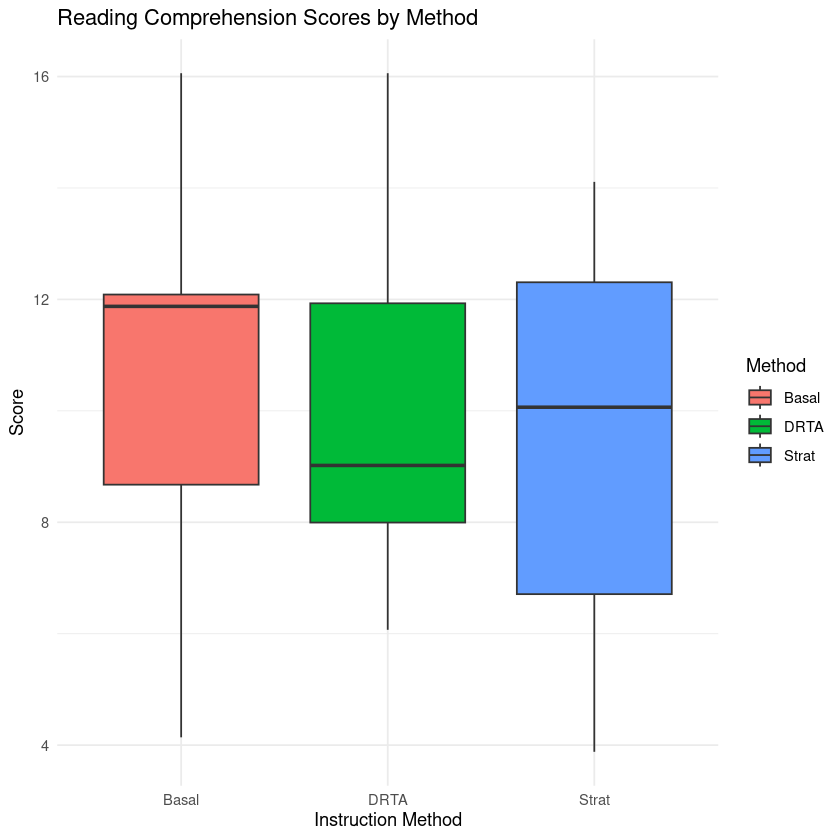

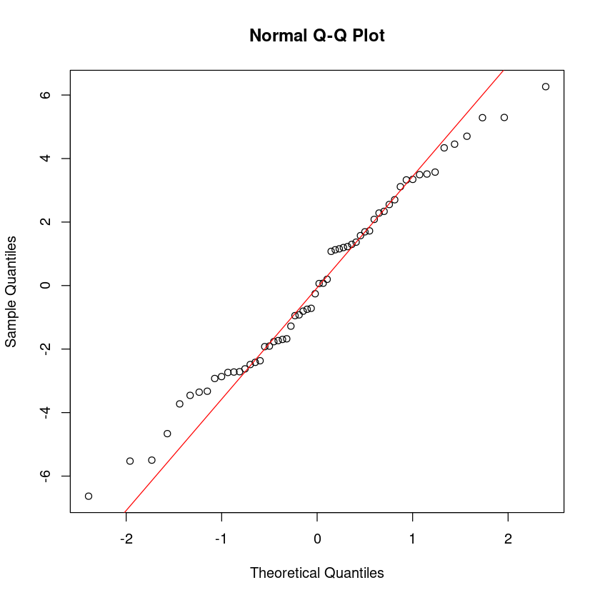

```r
Basal = c(4.14, 6.11, 8.85, 11.93, 16.06,
           15.11, 14.10, 11.85, 12.00, 8.15,
           13.11, 9.04, 12.07, 11.97, 11.90,
           9.85, 8.06, 12.14, 10.97, 8.05)

DRTA =  c(6.93, 6.87, 11.88, 9.87, 16.06,
          15.09, 8.85, 8.10, 13.14, 12.08,
          7.06, 6.07, 8.03, 9.05, 9.08,
          7.89, 8.99, 12.91, 9.86, 8.12)

Strat = c(11.13, 7.04, 3.88, 6.92, 6.99,
           6.08, 11.10, 14.11, 12.98, 9.15,
           12.11, 12.92, 3.91, 12.90, 5.95,
           11.96, 6.05, 10.98, 13.86, 8.13)

scores = c(Basal, DRTA, Strat)
group = factor(rep(c("Basal", "DRTA", "Strat"), each = 20))

dat = data.frame(
  Score = scores,
  Method = group
)

# Boxplots for group comparison
ggplot(dat, aes(x = Method, y = Score, fill = Method)) +
  geom_boxplot() +
  theme_minimal() +
  labs(title = "Reading Comprehension Scores by Method",
       y = "Score", x = "Instruction Method")


#Run One-way ANOVA
fit = aov(Score ~ Method, data = dat)
summary(fit)

#Levene’s Test for homogeneity of variance
leveneTest(Score ~ Method, data = dat)

# Normality checks
# Shapiro–Wilk test of residuals
shapiro.test(residuals(fit))

# QQ plot of residuals
qqnorm(residuals(fit))
qqline(residuals(fit), col = "red")
```